# Bar Charts

ozge.ozdamar@msgsu.edu.tr

March 06 2021

**references**

http://www.datavizcatalogue.com/methods/bar_chart.html

http://www.wikihow.com/Make-Bar-Graphs

**libraries**

```r
.packages = c("vcd","plotrix","plotly","lattice","ggplot2","tidyverse","flexclust","googleVis","plotrix","grid","gridExtra","sciplot")
.inst <- .packages %in% installed.packages()
if(length(.packages[!.inst]) > 0) install.packages(.packages[!.inst])
lapply(.packages, require, character.only=TRUE)
```

**functions**

```r
graphics::barplot()
plotrix::symbolbarplot(), multhist(), barlabels(), gap.barplot(), plotH(), barp()
LSD::heatbarplot()
epade::bar.plot.ade(), bar3d.ade()
anim.plots::anim.barplot()
UsingR::superbarplot(), squareplot()
rworldmap::barplotCountryData()
gplots::barplot2(),ooplot()
Desctools::ConnLines()
cluster::bannerplot(), silhoutte()
miscset::ciplot()
tis::barplot2()
PerformanceAnalytics::chart.StackedBar()
```

# 1 Bar charts

Bar charts provide a useful alternative way of presenting a set of values associated with the levels of a factor.

1. Bar charts can be used for values other than proportions.
2. Bar charts use position on a common scale to encode their values.
3. This means they provide a better way of delivering information than pie charts.

**Important-distinction:** be aware of when making bar graphs: sometimes the bar heights represent counts of cases in the data set, and sometimes they represent values in the data set.

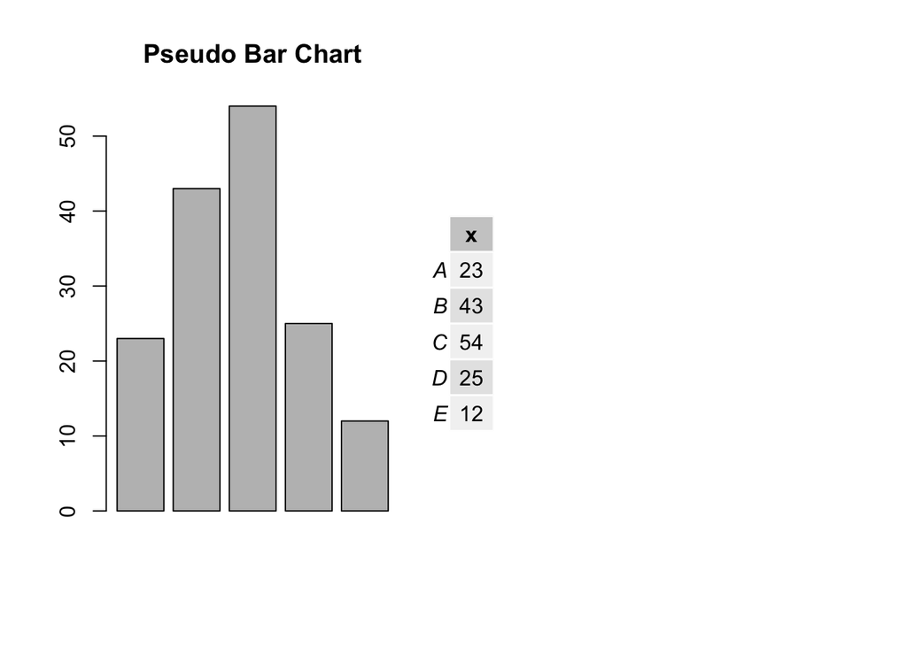

```r
pseudo<-data.frame(x=c(23,43,54,25,12))
row.names(pseudo)<-c("A","B","C","D","E")
par(mfrow=c(1,2))
graphics::barplot(pseudo$x, main="Pseudo Bar Chart")
grid.table(pseudo)
```

**stacked**

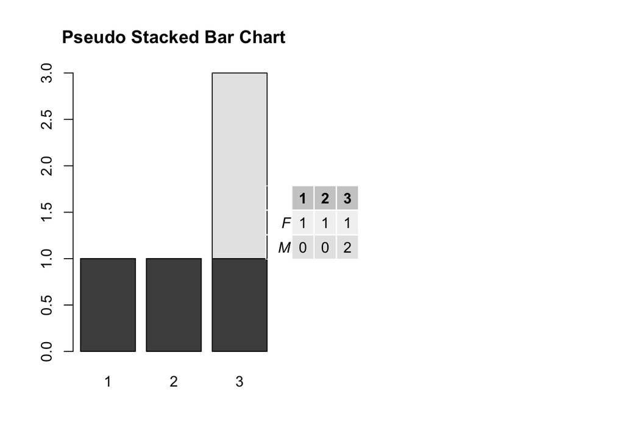

```r
datum<-data.frame(x1=c(23,43,54,25,12),x2=c("F","F","M","F","M"),x3=c(2,3,3,1,3))
row.names(datum)<-c("A","B","C","D","E")
par(mfrow=c(1,2))
graphics::barplot(table(datum$x2,datum$x3), main="Pseudo Stacked Bar Chart")
grid.table(table(datum$x2,datum$x3))
```

** grouped**

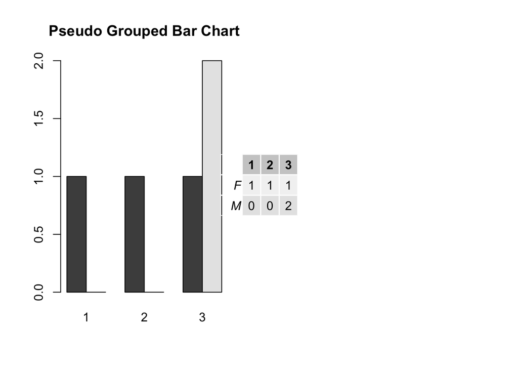

```r
par(mfrow=c(1,2))
graphics::barplot(table(datum$x2,datum$x3), beside=T, main="Pseudo Grouped Bar Chart")
grid.table(table(datum$x2,datum$x3))
```

**data**

```r
library(vcd) # for data
data(Arthritis)
head(Arthritis)
```

|  | ID | Treatment | Sex | Age | Improved |
| --- | --- | --- | --- | --- | --- |
| 1 | 57 | Treated | Male | 27 | Some |
| 2 | 46 | Treated | Male | 29 | None |
| 3 | 77 | Treated | Male | 30 | None |
| 4 | 17 | Treated | Male | 32 | Marked |
| 5 | 36 | Treated | Male | 46 | Marked |
| 6 | 23 | Treated | Male | 58 | Marked |

```r
str(Arthritis)
```

```
## 'data.frame':    84 obs. of  5 variables:
##  $ ID       : int  57 46 77 17 36 23 75 39 33 55 ...
##  $ Treatment: Factor w/ 2 levels "Placebo","Treated": 2 2 2 2 2 2 2 2 2 2 ...
##  $ Sex      : Factor w/ 2 levels "Female","Male": 2 2 2 2 2 2 2 2 2 2 ...
##  $ Age      : int  27 29 30 32 46 58 59 59 63 63 ...
##  $ Improved : Ord.factor w/ 3 levels "None"<"Some"<..: 2 1 1 3 3 3 1 3 1 1 ...
```

# 2 graphics package

```r
barplot(height, width = 1, space = NULL, names.arg = NULL, legend.text = NULL,
        beside = FALSE, horiz = FALSE, density = NULL, angle = 45, col = NULL,
        border = par("fg"), main = NULL, sub = NULL, xlab = NULL, ylab = NULL,
        xlim = NULL, ylim = NULL, xpd = TRUE, log = "", axes = TRUE, axisnames = TRUE,
        cex.axis = par("cex.axis"), cex.names = par("cex.axis"), inside = TRUE,
        plot = TRUE, axis.lty = 0, offset = 0,  add = FALSE, args.legend = NULL, ...)
```

try a bar graph on Sex, Age and Improved respectively

```r
graphics::barplot(Arthritis$Sex)
graphics::barplot(Arthritis$Age)
graphics::barplot(Arthritis$Improved)
```

data manipulation:

```r
d1<- table(Arthritis$Improved)
d1
```

```
##
##   None   Some Marked
##     42     14     28
```

```r
d2<- table(Arthritis$Improved, Arthritis$Treatment)
d2
```

```
##
##          Placebo Treated
##   None        29      13
##   Some         7       7
##   Marked       7      21
```

## 2.1 Simple Bar Chart

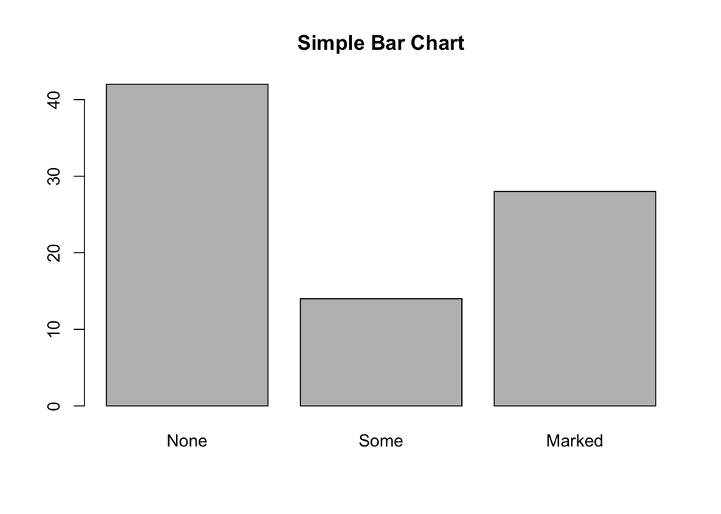

```r
barplot(d1, main = "Simple Bar Chart")
```

play with arguments

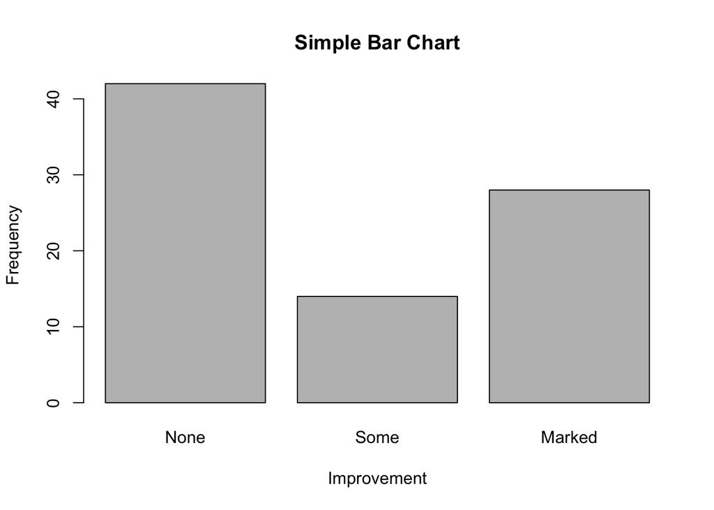

```r
barplot(d1, main = "Simple Bar Chart", xlab = "Improvement", ylab = "Frequency", width = 3)
```

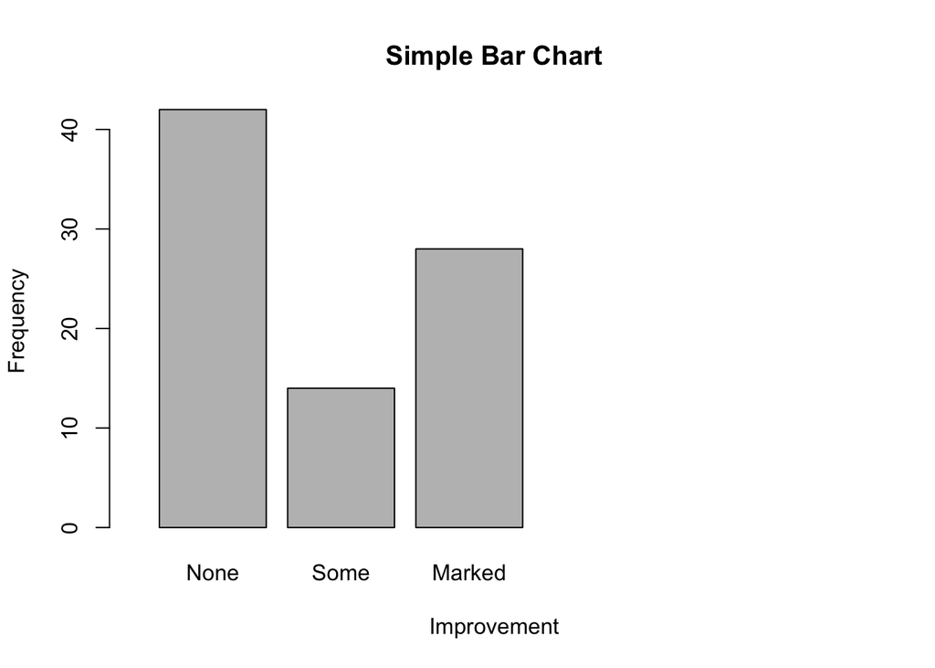

```r
barplot(d1, main = "Simple Bar Chart", xlab = "Improvement", ylab = "Frequency", width = 3, xlim=c(0,20)) # length no visible without xlim
```

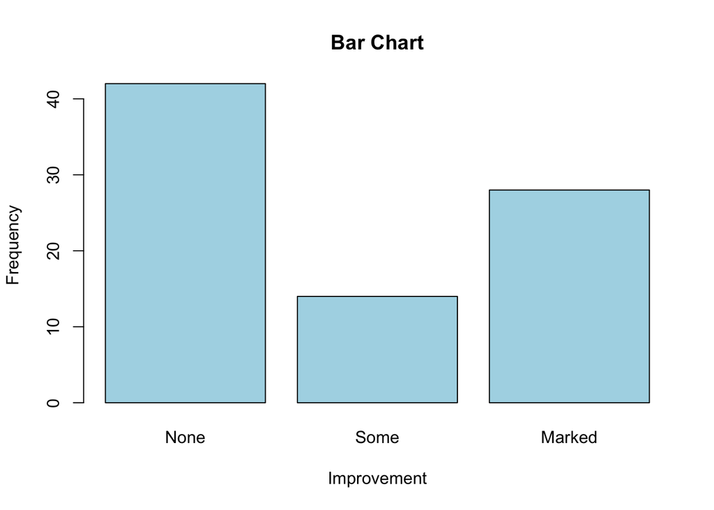

```r
barplot(d1, main = "Bar Chart", xlab = "Improvement", ylab = "Frequency", col = "lightblue")
```

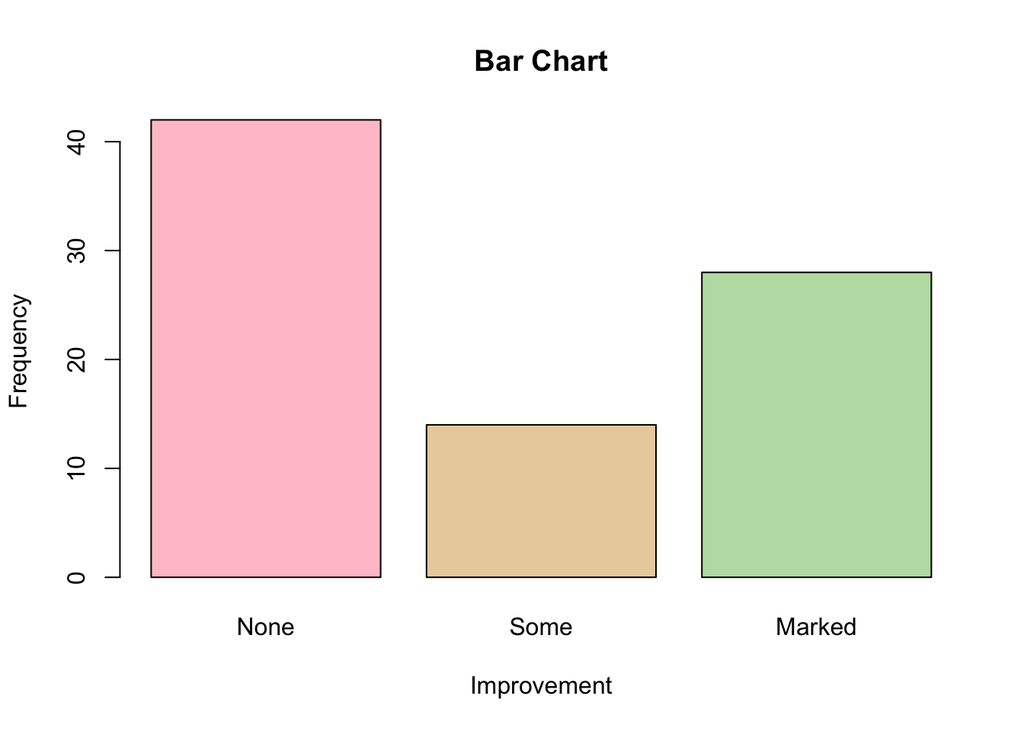

```r
barplot(d1, main = "Bar Chart", xlab = "Improvement", ylab = "Frequency", col = hcl(seq(0, 240, by = 60))) # tricolored
```

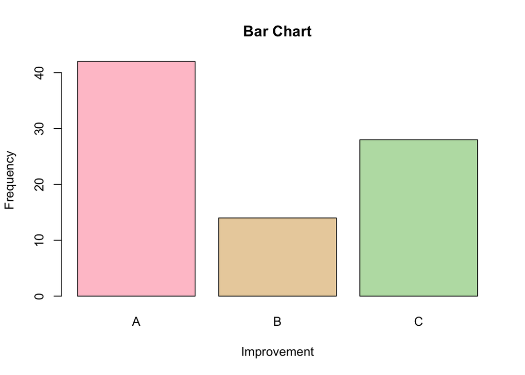

```r
barplot(d1, main = "Bar Chart", xlab = "Improvement", ylab = "Frequency", col = hcl(seq(0, 240, by = 60)), names.arg = c("A", "B", "C")) #change labels
```

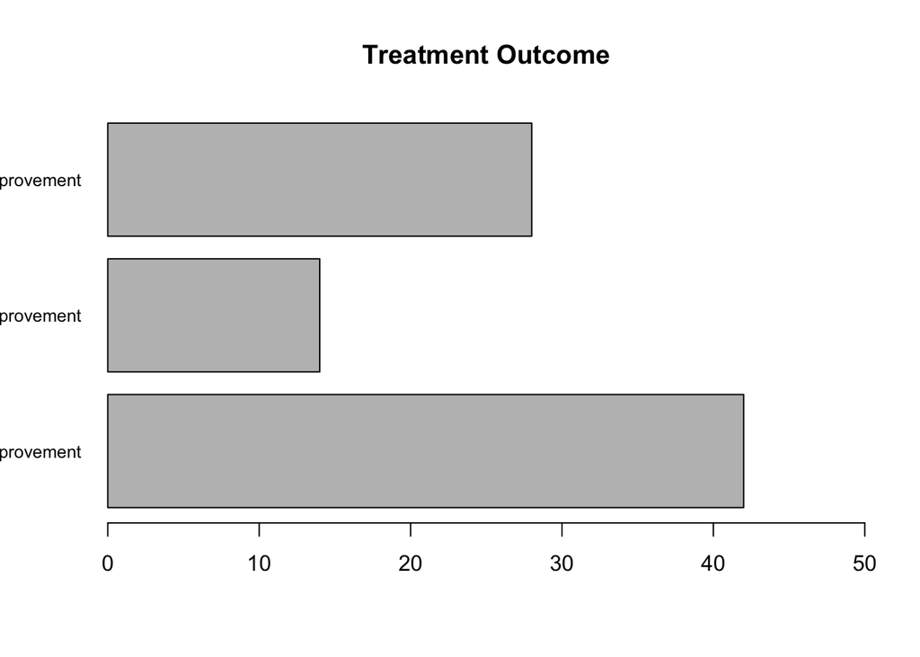

```r
barplot(d1, main = "Treatment Outcome", horiz = TRUE, cex.names = 0.8, cex.main = 1.2, las = 1, xlim = c(0,50), names.arg = c("No Improvement", "Some Improvement","Marked Improvement"))
```

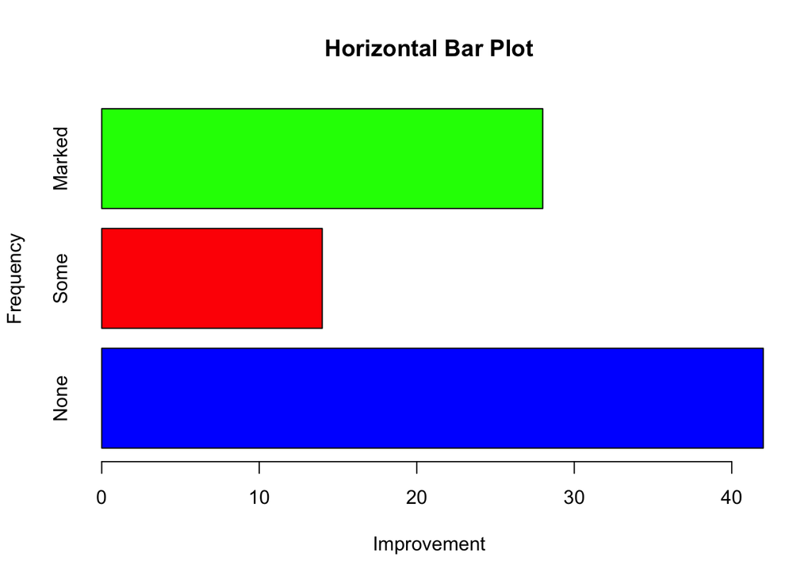

```r
barplot(d1, main="Horizontal Bar Plot",xlab="Improvement", ylab = "Frequency",horiz=T,col=c("blue","red","green"))
```

If the categorical variable to be plotted is a factor or ordered factor, you can create a vertical bar plot quickly with the `plot()` function. `Arthritis$Improved` is a factor:

```r
is.factor(Arthritis$Improved)
```

```
## [1] TRUE
```

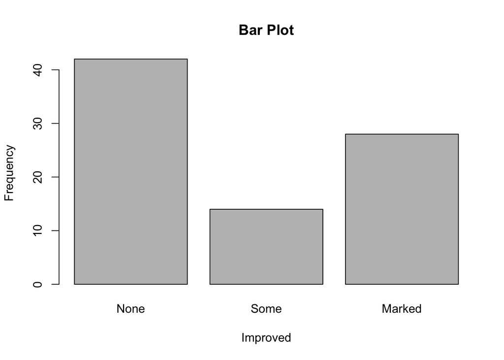

```r
plot(Arthritis$Improved, main = "Bar Plot", xlab="Improved", ylab = "Frequency")
```

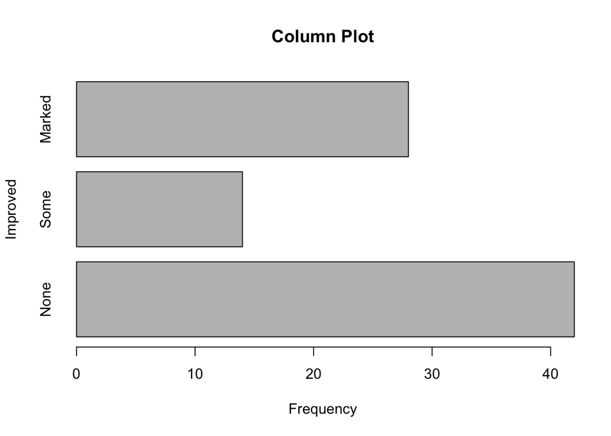

```r
plot(Arthritis$Improved, horiz = TRUE, main = "Column Plot",xlab = "Frequency", ylab = "Improved")
```

**example**

```r
library(flexclust) # for data
data("btw2009")
# view(btw2009)
str(btw2009)
library(tidyverse)
veri1<-btw2009 %>% group_by(state) %>% summarise(a=sum(votes/100000))
veri1
graphics::barplot(veri1$a, names.arg=veri$state)
graphics::barplot(veri1$a, names.arg=veri$state, las=2)
graphics::barplot(veri1$a, names.arg=veri$state, las=2, ylim=c(0,100))
```

```r
veri2<-veri1 %>% arrange(desc(a))
graphics::barplot(veri2$a, names.arg=veri2$state, las=2, ylim=c(0,100))
```

## 2.2 Stacked Bar Chart : Spine plot = Spinogram

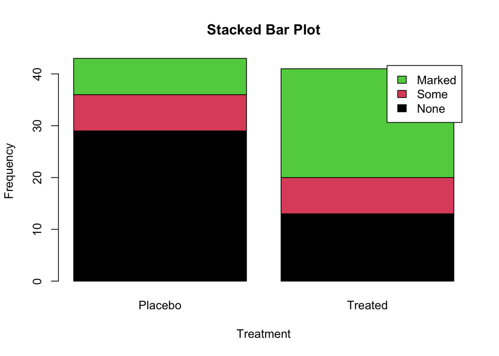

```r
barplot(d2, main = "Stacked Bar Plot", xlab = "Treatment", ylab=  "Frequency", col = palette(), legend.text = rownames(d2))
```

legend adjustment:

http://stackoverflow.com/questions/13936223/legends-in-barplot-not-appearing-properly

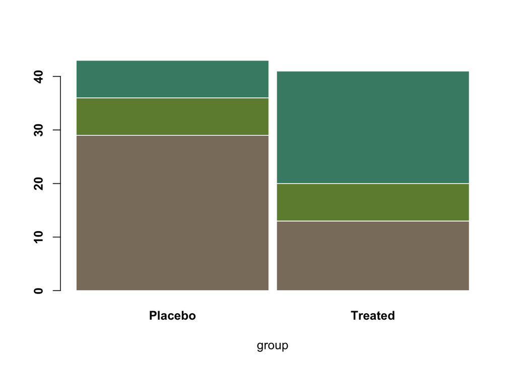

```r
barplot(d2, col = colors()[c(23,89,12)] , border = "white", space = 0.04, font.axis=2, xlab="group")
```

A stacked percent bar plot

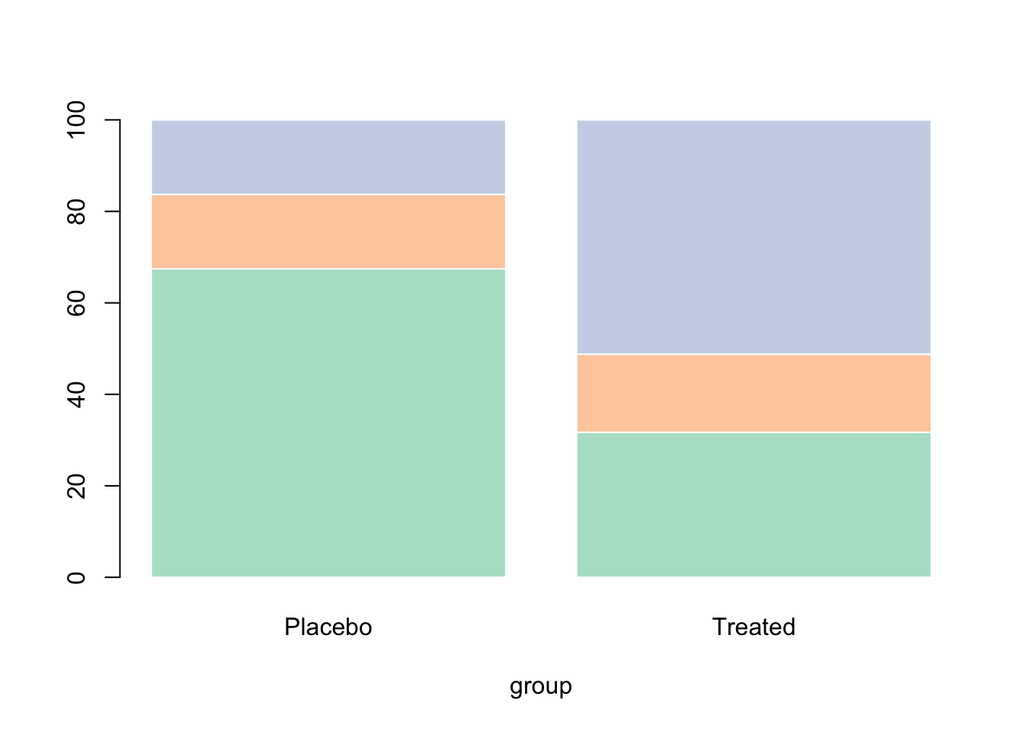

```r
library(RColorBrewer)
coul = brewer.pal(3, "Pastel2")

#Transform this data in %
data_percentage=apply(d2, 2, function(x){x*100/sum(x,na.rm=T)})

# Make a stacked barplot--> it will be in %!
barplot(data_percentage, col=coul , border="white", xlab="group")
```

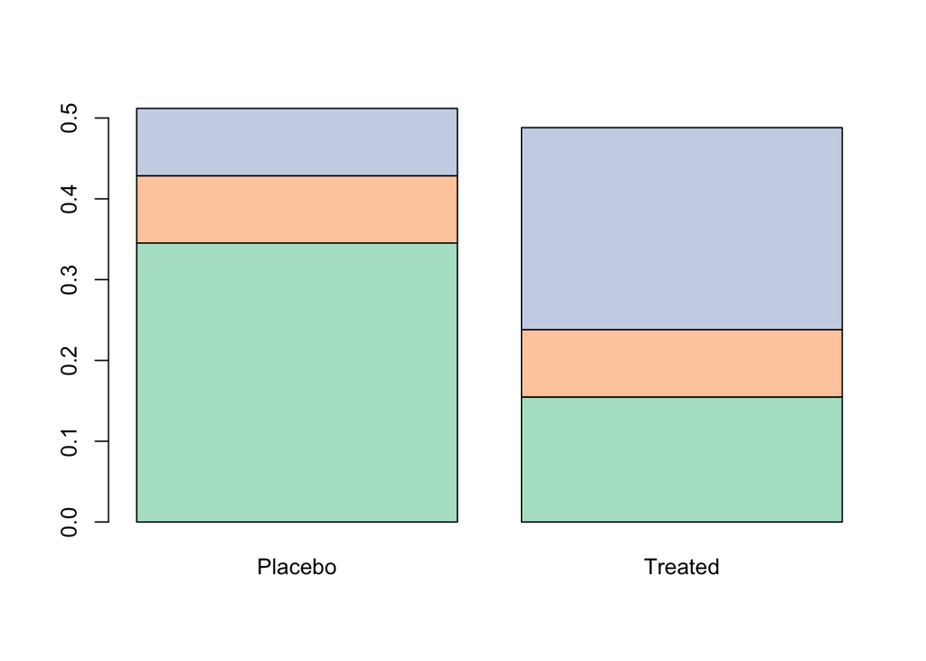

```r
barplot(prop.table(d2),col=coul)
```

graphics:spineplot

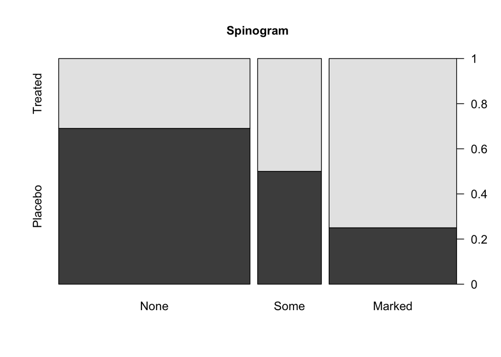

```r
vcd::spine(d2, main = "Spinogram")
```

## 2.3 grouped bar chart

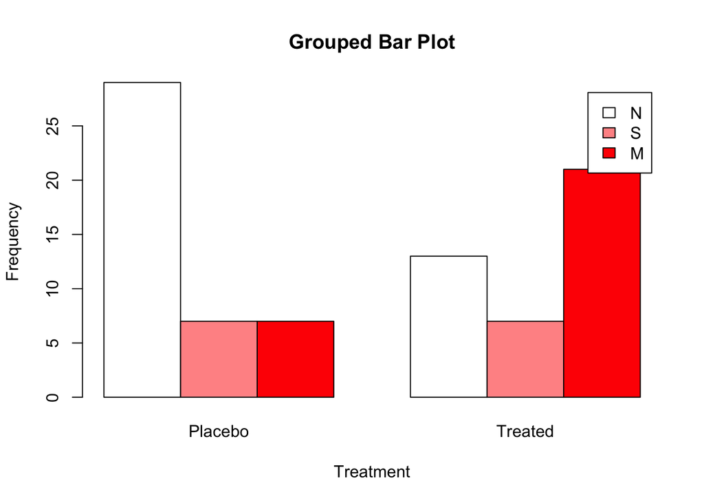

```r
barplot(d2, main = "Grouped Bar Plot", xlab = "Treatment", ylab = "Frequency", col = c(rgb(1, 0, 0, 0), rgb(1, 0, 0, 0.5), rgb(1, 0, 0, 1)), beside = TRUE, legend.text = c("N","S","M"))
```

# 3 lattice package

```r
barchart(x, data,panel = lattice.getOption("panel.barchart"),
         default.prepanel = lattice.getOption("prepanel.default.barchart"),
         box.ratio = 2,
         ...)
```

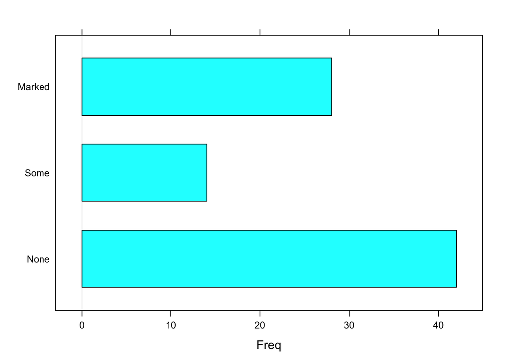

```r
library(lattice)
barchart(d1)
```

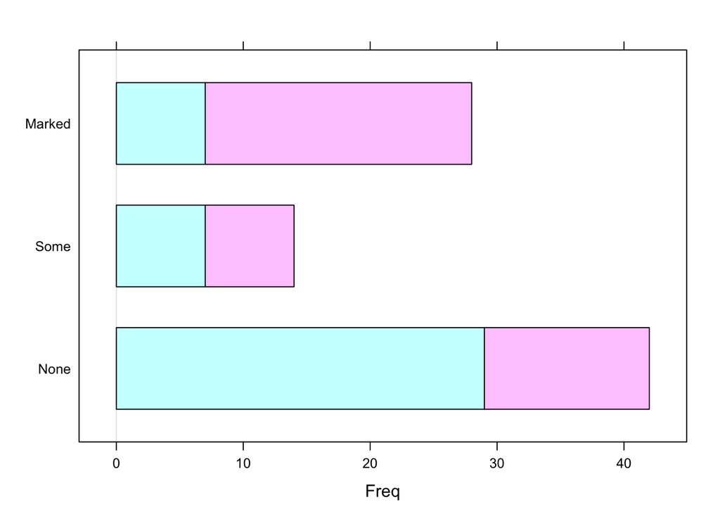

```r
barchart(d2)
```

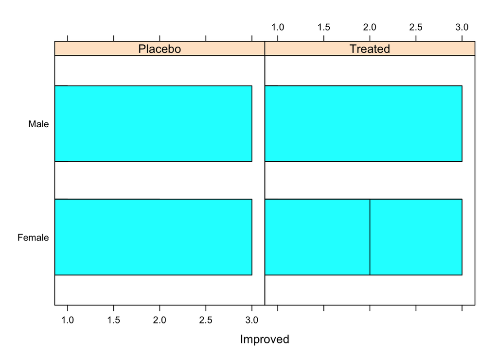

```r
barchart(Sex~Improved | Treatment, data=Arthritis)
```

# 4 ggplot2

https://rpubs.com/escott8908/RGC_Ch3_Gar_Graphs

https://learnr.wordpress.com/2009/03/17/ggplot2-barplots/

http://docs.ggplot2.org/0.9.3.1/geom_bar.html

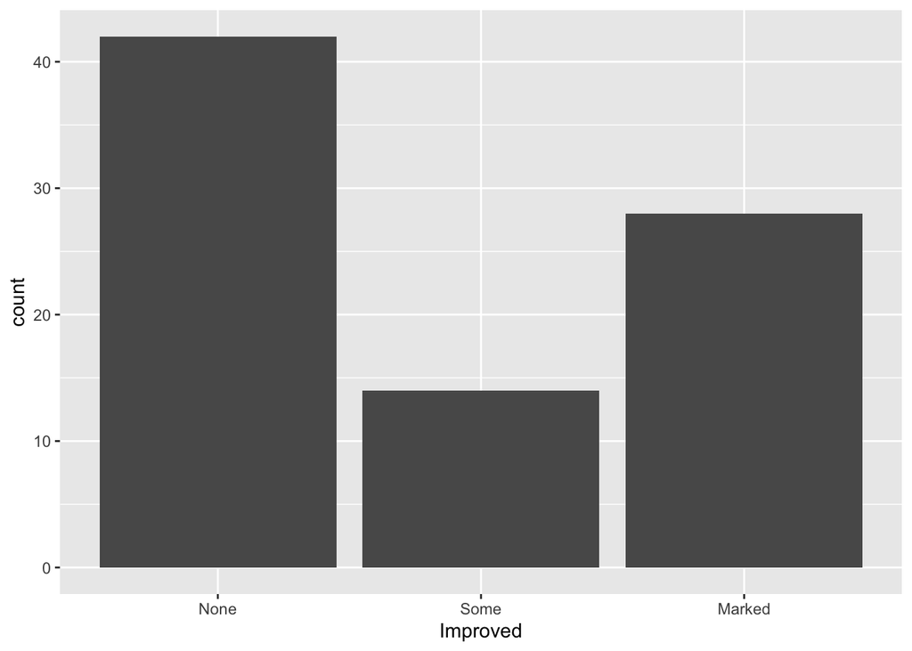

```r
library(ggplot2)
ggplot(Arthritis,aes(x=Improved))+geom_bar()
```

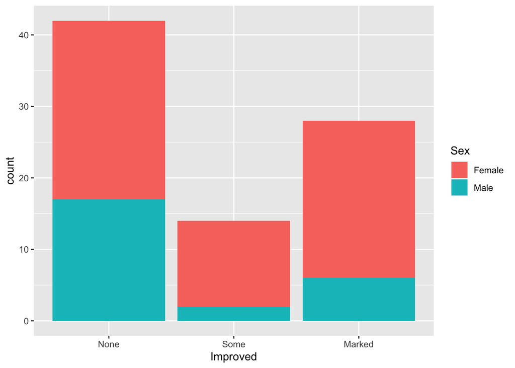

```r
ggplot(Arthritis,aes(x=Improved,fill=Sex))+geom_bar()
```

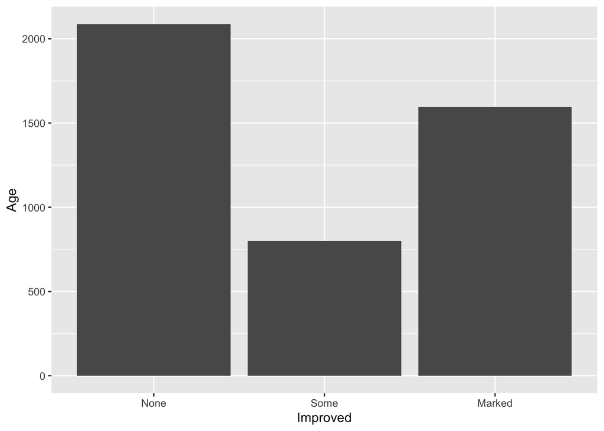

```r
ggplot(Arthritis,aes(x=Improved,y=Age))+geom_bar(stat="identity")
```

## 4.1 interactive

** googleVis package **

```r
g<-gvisBarChart(as.data.frame(d1))
plot(g)
```

```
## starting httpd help server ... done
```

```r
g<-gvisBarChart(as.data.frame(d2),options = list(isStacked=TRUE))
plot(g)
```

** `highcharts` package**

https://www.highcharts.com/blog/data-science/highcharts-for-r-users/

https://www.kaggle.com/nulldata/beginners-guide-to-highchart-visual-in-r

https://www.htmlwidgets.org/showcase_highcharts.html

```r
library(highcharter)
```

## 4.2 `plotly` package

https://plot.ly/r/bar-charts/

## 4.3 `dygraphs` package

## 4.4 `ggiraph` package

## 4.5 `rCharts` package

http://www.rpubs.com/dnchari/rcharts

## 4.6 alternative charts

### 4.6.1 symbol bar chart

```r
symbolbarplot(height,width = 1, space = NULL, names.arg = NULL,
              legend.text = NULL, beside = FALSE,horiz=FALSE,col=heat.colors(NR),
              border = par("fg"), main = NULL, sub = NULL, xlab = NULL, ylab = NULL,
              xlim = NULL, ylim = NULL, axes = TRUE, axisnames = TRUE, inside = TRUE,
              plot = TRUE, rel.width = 0.8,  symbol = "circles", symbbox = TRUE,
              debug = FALSE,...)
```

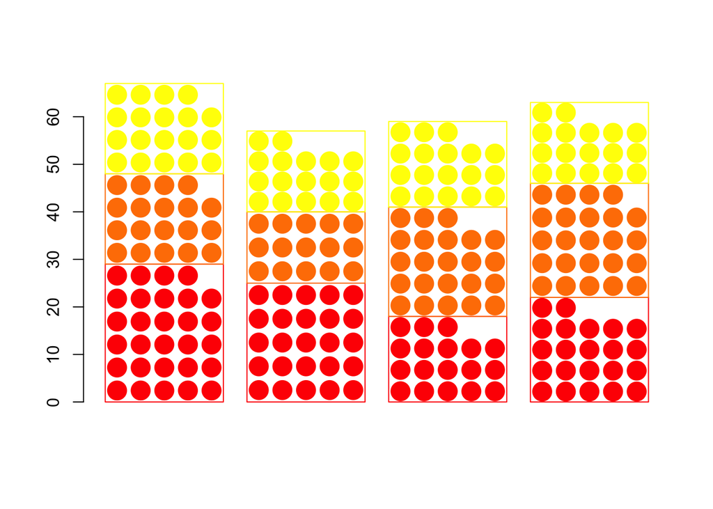

```r
library(plotrix)
set.seed(1001)
 bvals <- matrix(rpois(12,20),nrow=3)
 b <- symbolbarplot(bvals)
```

E.2.

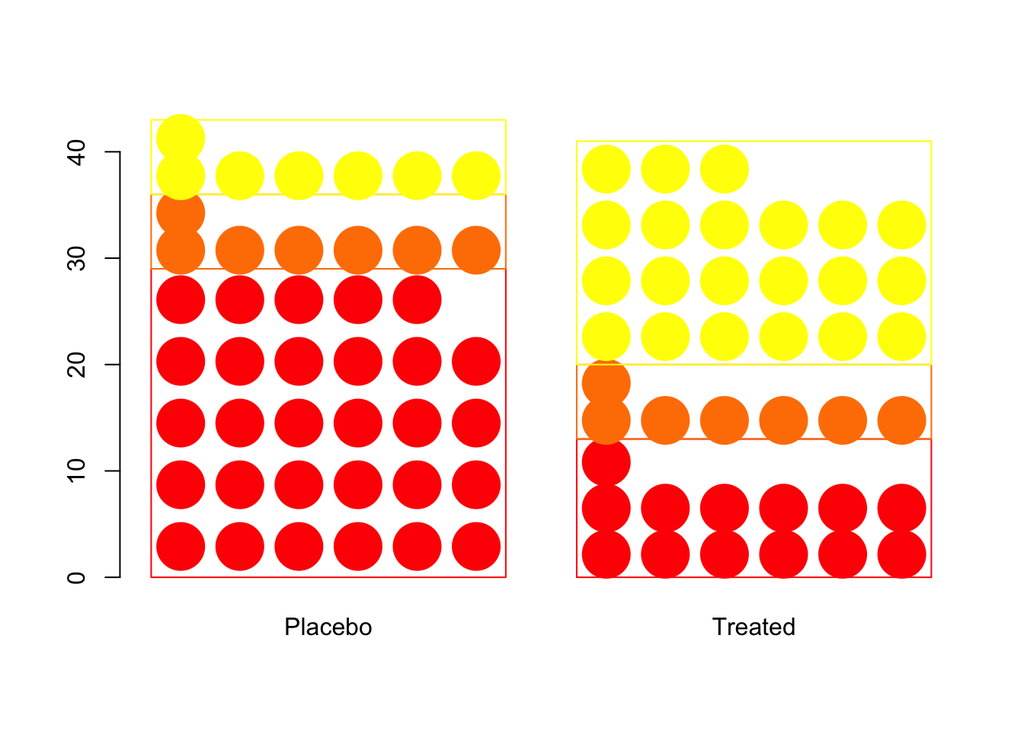

```r
symbolbarplot(d2)
```

Alternatives

http://annkemery.com/clustered-bar-chart/

http://peltiertech.com/stacked-bar-chart-alternatives/

http://www.ashander.info/posts/2015/04/barchart-alternatives-in-base-r/

http://timotheepoisot.fr/2013/02/17/stacked-barcharts/

http://peltiertech.com/marimekko-replacement-2-by-2-panel/

http://rgraphgallery.blogspot.com.tr/2013/04/rg69-circular-bar-plot.html

### 4.6.2 tornado plot:

https://rdrr.io/github/n8thangreen/plotCostEffectiveness/man/ggplot_tornado.html

```r
plotrix::pyramid.plot()
```

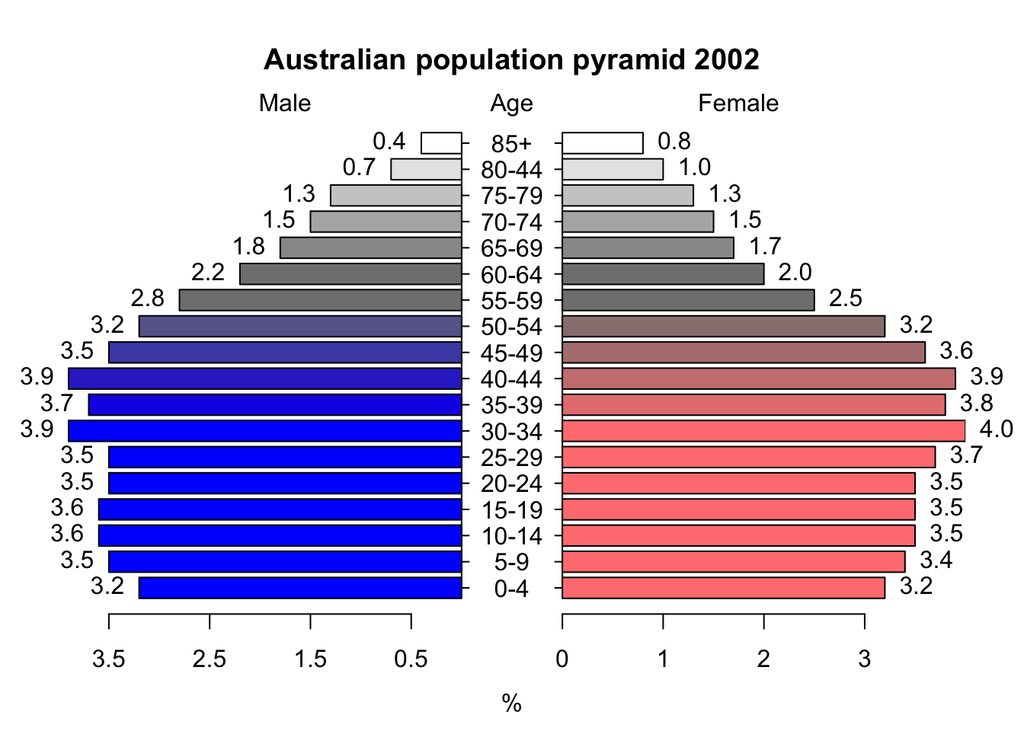

```
## 4 4
```

```r
xy.pop<-c(3.2,3.5,3.6,3.6,3.5,3.5,3.9,3.7,3.9,3.5,3.2,2.8,2.2,1.8,
  1.5,1.3,0.7,0.4)
 xx.pop<-c(3.2,3.4,3.5,3.5,3.5,3.7,4,3.8,3.9,3.6,3.2,2.5,2,1.7,1.5,
  1.3,1,0.8)
 agelabels<-c("0-4","5-9","10-14","15-19","20-24","25-29","30-34",
  "35-39","40-44","45-49","50-54","55-59","60-64","65-69","70-74",
  "75-79","80-44","85+")
 mcol<-color.gradient(c(0,0,0.5,1),c(0,0,0.5,1),c(1,1,0.5,1),18)
 fcol<-color.gradient(c(1,1,0.5,1),c(0.5,0.5,0.5,1),c(0.5,0.5,0.5,1),18)
 par(mar=pyramid.plot(xy.pop,xx.pop,labels=agelabels,
  main="Australian population pyramid 2002",lxcol=mcol,rxcol=fcol,
  gap=0.5,show.values=TRUE))
```

```r
 # three column matrices
 avtemp<-c(seq(11,2,by=-1),rep(2:6,each=2),seq(11,2,by=-1))
 malecook<-matrix(avtemp+sample(-2:2,30,TRUE),ncol=3)
 femalecook<-matrix(avtemp+sample(-2:2,30,TRUE),ncol=3)
 # group by age
 agegrps<-c("0-10","11-20","21-30","31-40","41-50","51-60",
  "61-70","71-80","81-90","91+")
 oldmar<-pyramid.plot(malecook,femalecook,labels=agegrps,
  unit="Bowls per month",lxcol=c("#ff0000","#eeee88","#0000ff"),
  rxcol=c("#ff0000","#eeee88","#0000ff"),laxlab=c(0,10,20,30),
  raxlab=c(0,10,20,30),top.labels=c("Males","Age","Females"),gap=4,
  do.first="plot_bg(\"#eedd55\")")
```

```
## 30 30
```

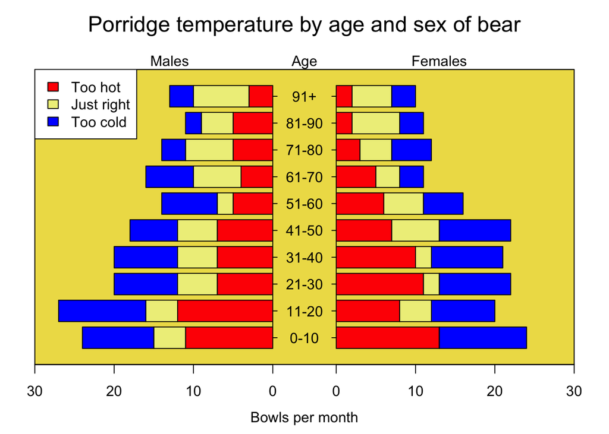

```r
 # put a box around it
 box()
 # give it a title
 mtext("Porridge temperature by age and sex of bear",3,2,cex=1.5)
 # stick in a legend
 legend(par("usr")[1],11,c("Too hot","Just right","Too cold"),
  fill=c("#ff0000","#eeee88","#0000ff"))
```

```r
 # don't forget to restore the margins and background
 par(mar=oldmar,bg="transparent")
```

```r
library(mc2d)
```

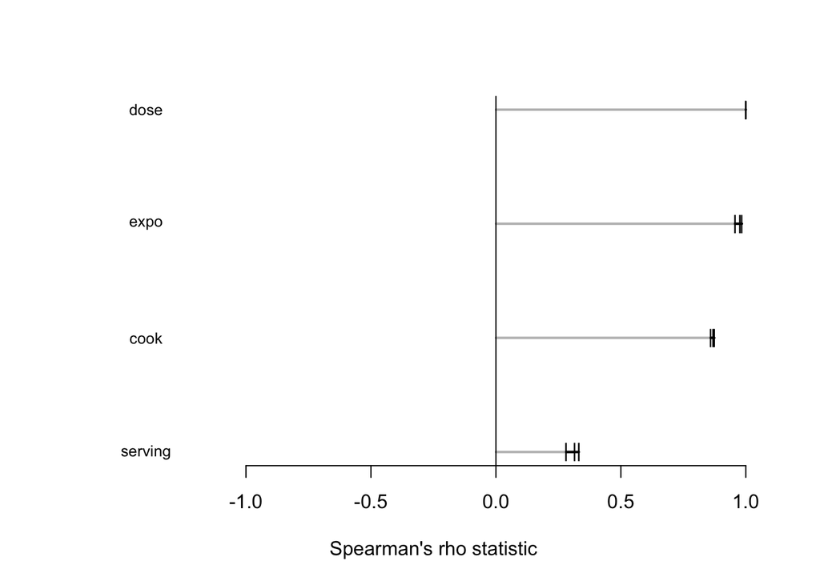

```r
data(ec)
x <- evalmcmod(ec$modEC2, nsv=100, nsu=100, seed=666)
tor <- tornado(x, 7)
plot(tor)
```